# Tarea4

Javier Montiel González

24/10/2020

# Ejercicio 1

Matriz de correlaciones

```
##      [,1] [,2] [,3]
## [1,] 1.00 0.63 0.45
## [2,] 0.63 1.00 0.35
## [3,] 0.45 0.35 1.00
```

Al aplicar el método de máxima verosimilitud del análisis de factores con m=1 obtenemos lo siguiente:

```
##
## Call:
## factanal(factors = 1, covmat = rho)
##
## Uniquenesses:
## [1] 0.19 0.51 0.75
##
## Loadings:
##      Factor1
## [1,] 0.9
## [2,] 0.7
## [3,] 0.5
##
##                Factor1
## SS loadings      1.550
## Proportion Var   0.517
##
## The degrees of freedom for the model is 0 and the fit was 0
```

Calculamos $LL'+\Psi$

```r
L%*%t(L)+psi
```

```
##           [,1]      [,2]      [,3]
## [1,] 1.0000003 0.6299992 0.4499997
## [2,] 0.6299992 1.0000022 0.3500010
## [3,] 0.4499997 0.3500010 0.9999999
```

Por lo tanto, $\rho=LL'+\Psi$, salvo por errores numéricos.

# Ejercicio 5

Datos de monitoreo atmosférico (REDMA)

Para la creación de la base de datos se tomaron los regitros de las estaciones que midieran los tres contaminantes (PM10, PST y PM25) considerados para el año 2019. Además, se descartaron las estaciones que tuvieran mediciones nulas en todos sus registros del año para alguno de los contaminantes. Así pues, las tres estaciones que se escogieron fueron: Tlanepantla (TLA), UAM Iztapalapa (UIZ) y Xalostoc (XAL). Se junto toda la información en una sola base con los siguientes campos: FECHA, ESTACIÓN, PM10, PST y PM25, con un toral de 151 observaciones.

Calculamos la correlación de las variable consideradas (PM10, PST y PM25)

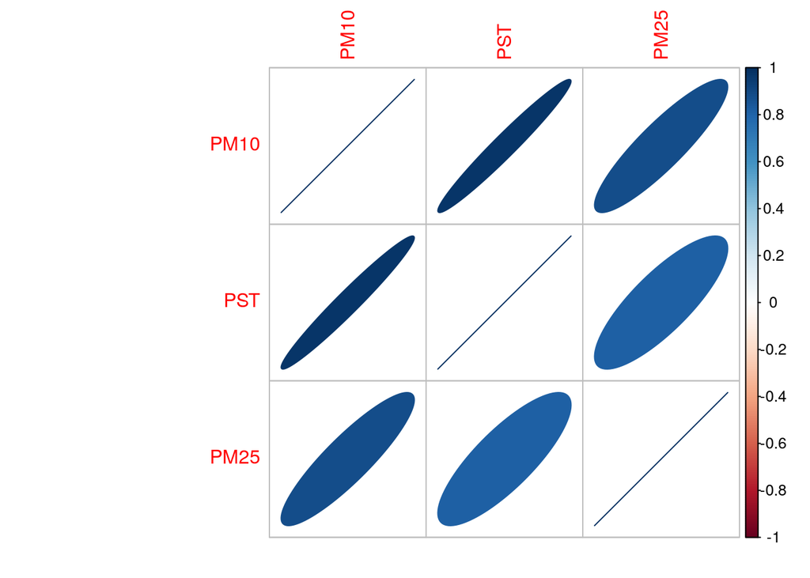

Nótese que las variables PM10 y PST están altamente correlacionadas y en un menor grado PM10 y PM25, por lo que se podrían tener hasta dos factores.

Aplicamos el método de máxima verosimilitud a la matriz de correlaciones y notamos que el método solo soporta un factor.

```
##
## Call:
## factanal(factors = 1, covmat = R)
##
## Uniquenesses:
##  PM10   PST  PM25
## 0.005 0.051 0.214
##
## Loadings:
##      Factor1
## PM10 0.998
## PST  0.974
## PM25 0.887
##
##                Factor1
## SS loadings       2.73
## Proportion Var    0.91
##
## The degrees of freedom for the model is 0 and the fit was 0.315
```

Observamos que la proporción de la varianza explicada por el modelo es de 0.91. Así pues, con un factor parece ser suficiente para describir las variables. Las cargas asignadas nos sugieren que el factor asigna pesos similares a PM10 y PST con PM25 casi una decima menos a PST. Dicho factor podría considerarse como la contaminación del aire en la CDMX.

Por otro lado, al aplicar el método de componentes principales a la matriz de covarianzas obtenemos lo siguiente:

```
##   PM10    PST   PM25
## -24.27 -44.67  -9.02
```

La varianza explicada por el primer eigenvalor es de 0.9783, por lo que tomar un factor es razonable para describir a las variables. Resulta que en este caso las cargas tienen valores negativos y la variable PST tiene un mayor peso. En este caso, el factor podría considerarse como la calidad del aire, la cual es menor cuando hay una mayor concentración de particulas contaminantes en el aire.

Calculamos los scores:

#Máxima Verosimilutud

```
##          Factor1
## [1,]  1.12533091
## [2,]  0.05394559
## [3,]  0.45102629
## [4,]  0.76219484
## [5,] -0.99290075
## [6,]  0.26554906
```

#Componentes principales

```
## [1]  0.076584615  0.004169147  0.048964136  0.045595140 -0.058181560
## [6]  0.017573878
```

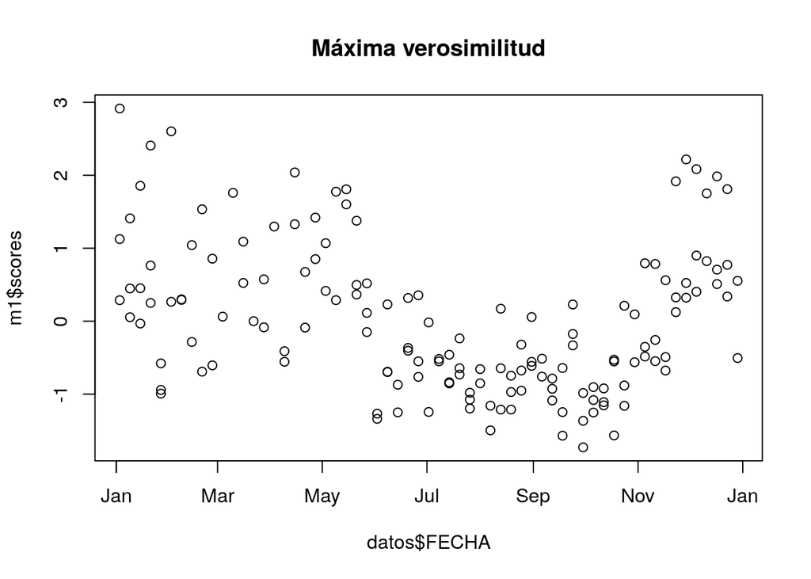

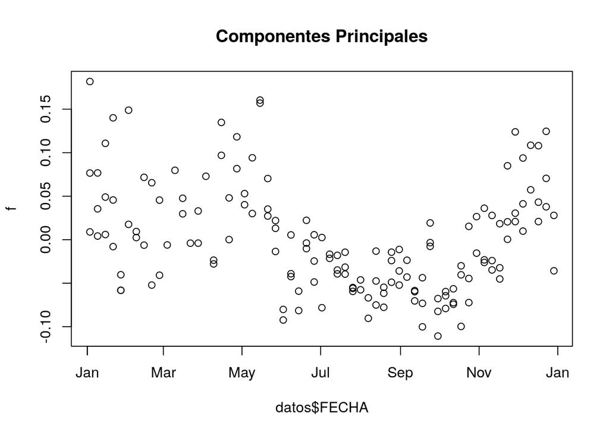